# Gender, Degrees and Wages: The Bayesian Workflow Applied to US Census Data

Thilde Terkelsen & Timo Röder

May 13, 2018

# Introduction

In this project we apply the Bayesian workflow to US census data from the years 2012 to 2016 in order to model wages and gender wage differences for college graduates from three academic fields living in New York state and Texas.

The gender wage gap, i.e. the average difference in pay between men and women, continues to be a subject of great debate in academia, media, politics as well as in more informal settings. Extensive studies on the wage gap’s underlying mechanisms and its historical trends have arrived at somewhat varying conclusions. This is not too surprising: setting up appropriate study designs and statistical models to study people’s wages is a fairly complex endeavour, as there are countless factors influencing the wage any individual receives. Variables such as educational level, field of study, maternity leave, work-life balance or even the income of an individual’s parents, to name a few, confound the question of whether the differences in salaries observed is in fact due to gender bias or simply an artefact of other social, economic or familial circumstances.

An extensive report titled “Graduating to a Pay Gap” by Corbett and Hill (2012) explores the gender difference in US wages one year after graduation. Corbett and Hill compared the salaries of recent graduates who reported working the same number of hours per week, and found that one year after graduation women earned ~18% less than their male counterparts. As there are differences regarding the college majors and jobs that men and women tend to choose – for instance, men are more likely to choose fields with relatively higher salaries such as engineering and computer science – the study grouped college majors into more general categories. Analyses were then performed seperately for each category and compared afterwards. While the study only found minor wage differences for majors in humanities, education and health sciences, there were significant gender wage gaps within the fields of engineering, computer science, business and social sciences.

Corbett, Christianne, and Catherine Hill. “Graduating to a Pay Gap: The Earnings of Women and Men One Year after College Graduation. American Association of University Women.” 1111 Sixteenth Street NW, Washington, DC 20036 (2012).

While the gender wage gap has shrunk in the US and other developed countries over the last 30 years, this wage convergence seems to stagnate at the moment . Along similar lines, a recent study of historical labour data has questioned the notion that some of the gender wage gap can still be attributed to gender differences in education . In the study, Blau and Kahn show that while in 1980 approximately 21.1% of the wage gap could be explained by work experience and 2.6% by educational level, by 2010 those numbers have decreased to 14.1% and -5.9% respectively, indicating that education is not a factor at all – if anything, women nowadays earn too little compared to their educational level.

Heathcote, Jonathan, Kjetil Storesletten, and Giovanni L. Violante. “The macroeconomic implications of rising wage inequality in the United States.” Journal of political economy 118.4 (2010): 681-722.

Blau, Francine D., and Lawrence M. Kahn. “The gender wage gap: Extent, trends, and explanations.” Journal of Economic Literature 55.3 (2017): 789-865.

Coming back to this project, it should be said that our scope is a lot smaller compared to these studies. We have not even attempted to disentangle the possible mechanisms underlying the wage gap.

Instead, our approach is rather descriptive: we set out to investigate wage as a function of people’s age and how this association may affect the gender wage gap – does the gap grow or shrink when looking at different age cohorts? Is such an effect equally strong across different fields of work and different states or are wages consistently more equal in some of these groups ? These are questions we would like to approach by applying the Bayesian workflow presented in the course.

While we cannot claim that the presented work provides groundbreaking answers to any unsolved research questions surrounding the gender wage gap, we hope that our report is still an informative and enjoyable read.

# Data

## From raw data to start of analysis

The data sources as well as some preliminary data cleaning steps are inspired by a *FiveThirtyEight* article from 2014: [*The Economic Guide To Picking A College Major*](https://fivethirtyeight.com/features/the-economic-guide-to-picking-a-college-major/).

Our primary data source is the American Community Survey (ACS) Public Use Microdata Sample (PUMS) conducted by the United States Census Bureau. The ACS conducts surveys of around 3.5 million households each year.

We are using the multiyear PUMS file covering census data for the years 2012 to 2016, which contains records on ~16 million individual residents. It can be downloaded as `zip` file by selecting “United States Population Records” from [this website](https://factfinder.census.gov/faces/tableservices/jsf/pages/productview.xhtml?pid=ACS_pums_csv_2012_2016&prodType=document). The `zip` file contains four large `csv` files which together cover the complete dataset. Additional information on the PUMS files is provided on the US Census Bureau’s website: they provide a general overview ([link to PDF](https://www.census.gov/content/dam/Census/programs-surveys/acs/guidance/training-presentations/20180214_PUMS.pdf)) as well as a data dictionary ([link to PDF](https://www2.census.gov/programs-surveys/acs/tech_docs/pums/data_dict/PUMS_Data_Dictionary_2012-2016.pdf)).

In the first data cleaning step, we remove individuals who did not graduate college (see R script [here](https://github.com/roeder/BDA_project/blob/master/scripts/clean_raw_csv.R)) and write the remaining 3,489,070 entries to a file called `us16_filtered.csv`.

Next up, we add information about college majors by merging our dataset with a lookup file called `majors-list.csv` prepared by *FiveThirtyEight* ([GitHub link](https://github.com/fivethirtyeight/data/blob/master/college-majors/majors-list.csv)). This lookup file matches the `FOD1P` codes used in the PUMS to actual names of the corresponding college majors. Additionally, these college majors are grouped into categories as used in a major 2011 study .

Carnevale et al., “What’s It Worth?: The Economic Value of College Majors.” Georgetown University Center on Education and the Workforce, 2011. [Website](http://cew.georgetown.edu/whatsitworth)

You can find the R script we used to merge datasets [on GitHub](https://github.com/roeder/BDA_project/blob/master/scripts/aggregate_us_16.R). This script also converts all wages reported before 2016 to inflation-adjusted wages equivalent to 2016 dollars, before writing selected columns for the 3,489,070 entries to a file called `selected_vars.csv`.

## Intermission: what is it we actually want to do?

Before moving on with the data preparation steps, it is probably a good idea to set the stage regarding what we want to model and why. Hopefully, this will make some of the following sections easier to follow.

As touched upon in the introduction, our intention here is to run relatively straightforward hierarchical regression models in order to model wages across different ages. Doing this in a Bayesian setting of course allows us to draw posterior predictive samples from the fitted models and we can use these posterior draws to answer some questions about the data.

For instance, you will see that the wage gap in absolute dollar values is substantially smaller when looking at education graduates as opposed to business graduates. However, wages are generally lower in the education group, so the observation about the wage gap might just be a side effect of this general difference in wages. Drawing posterior predicitve samples allows us to check if the difference in the wage gap holds up when looking at relative values rather than absolute ones.

## Selecting the data subset

The file `selected_vars.csv` is the starting point for our actual analysis:

```r
library(readr)
selected_vars <- read_csv("data/selected_vars.csv")
selected_vars
```

```
## # A tibble: 3,489,070 x 9
##     SERIALNO    ST  AGEP   SEX FOD1P Major  Major_Category real_total_earn
##        <dbl> <int> <int> <int> <int> <chr>  <chr>                    <dbl>
##  1   2.01e¹²    13    69     1  4101 PHYSI… Industrial Ar…           36961
##  2   2.01e¹²    13    53     2  2304 ELEME… Education                41185
##  3   2.01e¹²    13    34     2  1100 GENER… Agriculture &…            4435
##  4   2.01e¹²    13    56     1  6203 BUSIN… Business                 13728
##  5   2.01e¹²     6    49     1  2414 MECHA… Engineering              72866
##  6   2.01e¹²     6    48     2  3600 BIOLO… Biology & Lif…          211206
##  7   2.01e¹²     6    50     2  2300 GENER… Education                84482
##  8   2.01e¹²     5    67     2  6004 COMME… Arts                     10455
##  9   2.01e¹²     6    59     1  5003 CHEMI… Physical Scie…               0
## 10   2.01e¹²     6    54     2  2901 FAMIL… Industrial Ar…               0
## # ... with 3,489,060 more rows, and 1 more variable: real_wage <dbl>
```

It contains nine variables:

- `SERIALNO`: ID number for each entry
- `ST`: two-digit code for US states
- `AGEP`: age of survey respondent (at time of answering)
- `SEX`: survey respondent’s gender
- `FOD1P`: four-digit code for college major
- `Major`: corresponding college major (173 majors in total)
- `Major_Category`: college major category (16 categories in total)
- `real_total_earn`: inflation-adjusted reported yearly total earnings (in 2016 USD)
- `real_wage`: inflation-adjusted reported yearly wages (in 2016 USD)

While it would of course be most appropriate to conduct an analysis on the complete dataset, we chose to focus only on a select subset of entries in order to keep both computation times and model interpretation manageable. Our chosen subset consists of entries from two states and three major categories.

We choose New York and Texas as two similarly large states which should serve as decent stand-ins for politically opposed *blue states* (NY) and *red states* (TX). The major categories we focus on are business, education and health. We select the data subset with the following R code:

```r
library(dplyr)
nytx_df <- selected_vars %>%
  filter(ST %in% c(36, 48),
         Major_Category %in% c("Education", "Health", "Business"),
         real_wage > 0) %>%
  mutate(state = if_else(ST == 36, "NY", "TX"),
         sex = if_else(SEX == 1, "male", "female"))
```

Note that in the above code chunk, we also remove respondents who reported no wage and recode `ST` and `SEX` into the more explicit variables `state` and `sex`.

The resulting subset contains 148,490 entries, which can be broken down as follows:

```r
library(tidyr)
nytx_df %>%
  group_by(Major_Category, state, sex) %>%
  summarise(entries = n()) %>%
  spread(key = "sex", value = "entries") %>%
  mutate(ratio = female / male,
         total = male + female) %>%
  knitr::kable(., digits = 2, format.args = list(big.mark = ","),
               col.names = c("major category", "state", "female", "male",
                             "ratio (f/m)", "total"))
```

| major category | state | female | male | ratio (f/m) | total |
| --- | --- | --- | --- | --- | --- |
| Business | NY | 15,789 | 19,265 | 0.82 | 35,054 |
| Business | TX | 18,888 | 24,829 | 0.76 | 43,717 |
| Education | NY | 15,422 | 4,996 | 3.09 | 20,418 |
| Education | TX | 17,681 | 5,024 | 3.52 | 22,705 |
| Health | NY | 11,075 | 2,507 | 4.42 | 13,582 |
| Health | TX | 10,417 | 2,597 | 4.01 | 13,014 |

## Data summaries

In order to get an overview of the general trend in wages as a function of age, we plot the mean and variation of yearly wages across the age range from 20 to 70:

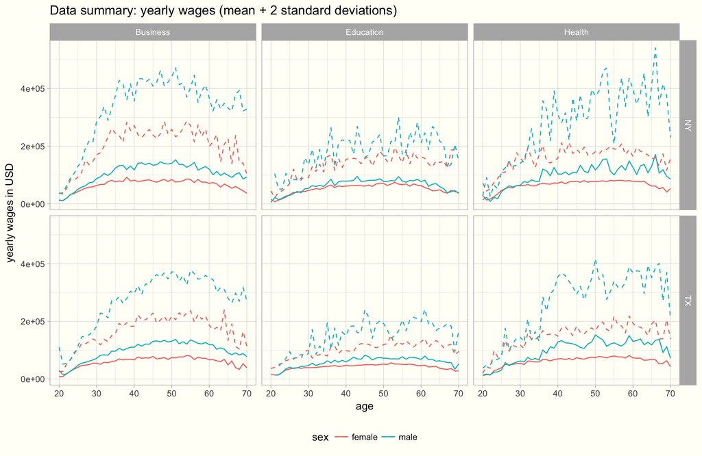

```r
library(ggplot2)
nytx_df %>%
  filter(AGEP >= 20,
         AGEP <= 70) %>%
  group_by(AGEP, sex, Major_Category, state) %>%
  summarise(mean_wage = mean(real_wage, na.rm = T),
            sd_wage = sd(real_wage, na.rm = T)) %>%
  ggplot(., aes(x = AGEP)) +
  geom_line(aes(y = mean_wage, colour = sex)) +
  geom_line(aes(y = mean_wage + 2 * sd_wage, colour = sex), linetype = "dashed") +
  ggtitle("Data summary: yearly wages (mean + 2 standard deviations)") +
  xlab("age") +
  ylab("yearly wages in USD") +
  facet_grid(state ~ Major_Category) +
  custom_ggtheme
```

We can see differences in wages, slopes as well as in the gender wage gap when comparing the different panels. Nothing here is too surprising: business graduates have the highest earning potential, followed by graduates in the field of health, and education graduates coming in last. Furthermore, it appears that wages grow steadily through people’s thirties and forties until growth starts to stall around the age of fifty. This observation is fairly consistent across all panels.

Looking at the gender wage gap, the gap is consistently smallest within education graduates (at least in terms of absolute numbers). While the gap within health and business ends up being roughly similar in older age cohorts, the way there is different: women with a business background seem to earn less than men right out of the gate, whereas wages only start to separate around age 35 for health graduates.

On a more technical note, we can also see that there is a lot of variation in the wages within each age cohort. This is not unexpected, however it has implications for our model choice: If we were to go ahead and use a regression model that directly models wage (with Gaussian noise) as a function of age, it is very likely that we would end up with negative wages when drawing posterior predictive samples from that model.

In order to avoid this, we log-transform the wage numbers before running our models. This will ensure that our posterior predictive samples are positive (after exponentiating them) – and has the convenient side-effect of lowering the impact of high outlier wages.

```r
model_df1 <- nytx_df %>%
  mutate(log_wage = log(real_wage))
```

While using Gaussian distributions to describe the wage distributions at each age point is of course still an approximation, it is not a terribly outrageous one after log-transforming the wages. We can see this in the violin plots of select age cohorts (we only show eight because it would start to get cramped with more age cohorts):

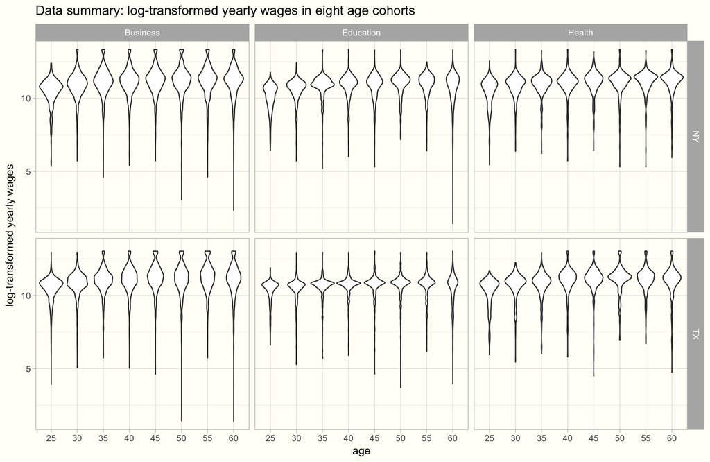

```r
model_df1 %>%
  filter(AGEP %in% seq(25, 60, 5)) %>%
  ggplot(., aes(x = factor(AGEP), y = log_wage)) +
  geom_violin() +
  ggtitle("Data summary: log-transformed yearly wages in eight age cohorts") +
  xlab("age") +
  ylab("log-transformed yearly wages") +
  facet_grid(state ~ Major_Category) +
  custom_ggtheme
```

# Linear model: a simple start

To kick things off, we fit a hierarchical generalised linear model with Gaussian noise. As we have discovered when looking at the data summary earlier, wages start to stagnate around the age of fifty. Therefore, we will only fit the linear model in the age span 25 to 50 – this is where the wage growth happens.

```r
lin_df <- model_df1 %>%
  filter(AGEP >= 25,
         AGEP <= 50)
```

The resulting data frame `lin_df` still contains 85,843 entries. In order to keep computation times manageable, we reduce the size of the dataset by taking a random sample of 5,000 entries:

```r
set.seed(42)
prototype_lin_df <- lin_df %>%
  sample_n(size = 5000)
```

## Model fitting & convergence diagnostics

We can now go ahead and fit a hierarchical generalised linear model using the `stan_glmer()` function from `rstanarm`. Log-transformed wages will be fitted as a linear function of age with Gaussian noise. We want to allow for the slope of this function to be different between the genders, so we add `sex` as a grouping term. In addition, we specify the hierarchical groupings `Major_Category` and `state`.

```r
library(rstan)
library(rstanarm)

rstan_options(auto_write = TRUE)
options(mc.cores = parallel::detectCores() - 1)
```

```r
lin_fit <- stan_glmer(log_wage ~ (AGEP | sex) +
                        (1 | Major_Category) + (1 | state),
                           data = prototype_lin_df, family = gaussian())
```

Let’s have a look at the model fit summary, including parameter estimates and convergence diagnostics:

```r
knitr::kable(lin_fit$stan_summary, digits = 2)
```

|  | mean | se_mean | sd | 2.5% | 10% | 25% | 50% | 75% | 90% | 97.5% | n_eff | Rhat |
| --- | --- | --- | --- | --- | --- | --- | --- | --- | --- | --- | --- | --- |
| (Intercept) | 10.04 | 0.01 | 0.49 | 8.96 | 9.56 | 9.84 | 10.05 | 10.25 | 10.52 | 11.06 | 1183.90 | 1 |
| b[(Intercept) Major_Category:Business] | 0.08 | 0.01 | 0.27 | -0.41 | -0.15 | -0.02 | 0.08 | 0.17 | 0.31 | 0.68 | 1193.12 | 1 |
| b[(Intercept) Major_Category:Education] | -0.17 | 0.01 | 0.27 | -0.67 | -0.41 | -0.27 | -0.18 | -0.09 | 0.05 | 0.42 | 1205.35 | 1 |
| b[(Intercept) Major_Category:Health] | 0.11 | 0.01 | 0.27 | -0.38 | -0.12 | 0.01 | 0.10 | 0.20 | 0.33 | 0.71 | 1202.74 | 1 |
| b[(Intercept) Major_Category:_NEW_Major_Category] | 0.00 | 0.01 | 0.47 | -0.92 | -0.42 | -0.18 | 0.00 | 0.16 | 0.40 | 0.93 | 3367.31 | 1 |
| b[(Intercept) state:NY] | 0.06 | 0.01 | 0.38 | -0.72 | -0.21 | -0.02 | 0.06 | 0.16 | 0.34 | 0.83 | 1285.23 | 1 |
| b[(Intercept) state:TX] | -0.05 | 0.01 | 0.38 | -0.84 | -0.32 | -0.13 | -0.05 | 0.04 | 0.23 | 0.72 | 1284.40 | 1 |
| b[(Intercept) state:_NEW_state] | -0.01 | 0.01 | 0.57 | -1.12 | -0.42 | -0.13 | 0.00 | 0.13 | 0.39 | 1.06 | 3583.15 | 1 |
| b[(Intercept) sex:female] | 0.07 | 0.00 | 0.17 | -0.21 | -0.06 | -0.01 | 0.04 | 0.13 | 0.25 | 0.47 | 1371.92 | 1 |
| b[AGEP sex:female] | 0.02 | 0.00 | 0.00 | 0.01 | 0.01 | 0.01 | 0.02 | 0.02 | 0.02 | 0.02 | 3180.43 | 1 |
| b[(Intercept) sex:male] | -0.08 | 0.00 | 0.17 | -0.49 | -0.28 | -0.15 | -0.05 | 0.00 | 0.05 | 0.21 | 1613.56 | 1 |
| b[AGEP sex:male] | 0.03 | 0.00 | 0.00 | 0.02 | 0.03 | 0.03 | 0.03 | 0.03 | 0.03 | 0.04 | 2011.61 | 1 |
| b[(Intercept) sex:_NEW_sex] | 0.00 | 0.01 | 0.28 | -0.51 | -0.20 | -0.07 | 0.00 | 0.07 | 0.22 | 0.53 | 2672.37 | 1 |
| b[AGEP sex:_NEW_sex] | 0.00 | 0.00 | 0.10 | -0.20 | -0.08 | -0.03 | 0.00 | 0.03 | 0.08 | 0.20 | 2675.74 | 1 |
| sigma | 0.93 | 0.00 | 0.01 | 0.91 | 0.92 | 0.93 | 0.93 | 0.94 | 0.94 | 0.95 | 4000.00 | 1 |
| Sigma[Major_Category:(Intercept),(Intercept)] | 0.24 | 0.02 | 0.68 | 0.01 | 0.02 | 0.03 | 0.06 | 0.17 | 0.49 | 1.69 | 1709.67 | 1 |
| Sigma[state:(Intercept),(Intercept)] | 0.34 | 0.03 | 1.07 | 0.00 | 0.00 | 0.01 | 0.05 | 0.20 | 0.80 | 2.57 | 1502.46 | 1 |
| Sigma[sex:(Intercept),(Intercept)] | 0.08 | 0.01 | 0.31 | 0.00 | 0.00 | 0.00 | 0.02 | 0.06 | 0.16 | 0.49 | 2512.64 | 1 |
| Sigma[sex:AGEP,(Intercept)] | 0.00 | 0.00 | 0.03 | -0.05 | -0.01 | 0.00 | 0.00 | 0.00 | 0.01 | 0.04 | 1279.13 | 1 |
| Sigma[sex:AGEP,AGEP] | 0.01 | 0.00 | 0.02 | 0.00 | 0.00 | 0.00 | 0.00 | 0.01 | 0.02 | 0.07 | 1305.58 | 1 |
| mean_PPD | 10.87 | 0.00 | 0.02 | 10.83 | 10.85 | 10.86 | 10.87 | 10.88 | 10.89 | 10.91 | 3925.80 | 1 |
| log-posterior | -6775.89 | 0.12 | 3.78 | -6783.88 | -6780.79 | -6778.33 | -6775.70 | -6773.27 | -6771.17 | -6769.29 | 970.00 | 1 |